# Stan examples

## Introduction

Stan is a platform for running statistical computations, especially Bayesian data analysis. The mechanism by which it works (Hamiltonian Markov Chain Monte Carlo) is sophisticated. Rather than describing the technical mathematics “under the hood”, we’ll simply describe how to set up a model and compute a posterior distribution.

We’ll also see a nice dashboard that allows us to diagnose model fit and explore and visualize various properties of the posterior distribution.

The first time you run the code chunks in this file, it will take a while. Be patient. I’ve included options and code that will allow Stan to bypass a lot of the work R has to do the second time around (and every time thereafter, as long as you’re in the same R session).

## Preliminaries

Load necessary packages:

```r
library(rstan)
library(shinystan)
```

Stan will take a fair amount of time the first time it’s run on a model. The following bit of code tells Stan not to recompile code that has already been compiled once so that it won’t take so long after the first time.

```r
rstan_options(auto_write = TRUE)
```

We set the seed so that random processes look the same every time the document is run.

```r
set.seed(54321)
```

## Stan’s structure

Stan code looks quite different from R code. (Stan is actually coded in C.) We’ll see later, for example, that each line must terminate with a semicolon, and comments use two forward slashes.

There are three required code blocks in a Stan program. The first is called `data` and it reads in the raw data. The second is `parameters` in which you tell Stan the parameters for which you’re conducting statistical inference. The third is `model` where you describe the statistical model.

There are other, more advanced possibilities for code blocks, but those three suffice for a complete model.

## Storing the data

We re-create the analysis of 12 successes in 18 trials from the `Continuous_Bayes` notes.

Stan is a little particular about the form of the data. It requires a `list` from R. Here’s how we do that. First, just store the values we need.

```r
N <- 18  # Define the sample size
y <- c(rep(1, 12), rep(0, 6))  # 12 successes and 6 failures
```

The line defining `y` is just using an R trick to get 12 ones and 6 zeros. Observe:

```r
y
```

```
 [1] 1 1 1 1 1 1 1 1 1 1 1 1 0 0 0 0 0 0
```

Now we bundle `N` and `y` together into a list.

```r
stan_data <- list(N = N, y = y)
stan_data
```

```
$`N`
[1] 18

$y
 [1] 1 1 1 1 1 1 1 1 1 1 1 1 0 0 0 0 0 0
```

This is the format required by Stan for accessing the data.

## Uniform prior

We’ll start with assuming a uniform prior.

### The Stan code

R Markdown is awesome, so it gives us a way to create a Stan model within a code chunk. The resulting model is stored in the variable name specified by the `output.var` chunk option (in this case, `bin_unif`).

We also use the option `cache = TRUE` in the header of the code chunk. This chunk takes a while the first time it’s run; however, once the result is cached, it won’t run again even when you “Run All” code chunks. (You may also ignore any warnings that may appear below the chunk once it’s finished running.)

**Be aware that there is a bug in R notebooks that prevents the following Stan code chunk from appearing in the HTML file. So if you are looking at the HTML file, be sure to go back to the R notebook to see the Stan code.**

Let’s take a closer look at various pieces of the Stan code. Here is the `data` block:

```
data {
    int<lower = 0> N;
    int<lower = 0, upper = 1> y[N];
}
```

Notice that the two variables declared here are precisely the variables in the list `stan_data` (namely, `N`, and `y`). The `lower` and/or `upper` bounds in the definitions just serve as a check to make sure we are passing in data of the right form. (If invalid data is passed to Stan, the program will stop with an error.) The notation `y[N]` means that the variable `y` should be an array of `N` integers.

The `parameters` block is

```
parameters {
    real<lower = 0, upper = 1> theta;
}
```

This simply declares that we are interested in doing inference for a value called `theta`. The `lower` and `upper` bounds here serve a slightly different purpose. These tell Stan that it shouldn’t consider values of `theta` unless they lie between 0 and 1.

The `model` block is

```
model {
    theta ~ uniform(0, 1);  // prior
    y ~ bernoulli(theta);   // likelihood
}
```

The first line is saying that we start with a uniform prior on `theta`. Technically, this line is not required: the parameter declaration `real<lower = 0, upper = 1> theta` defines a uniform $(0, 1)$ prior on `theta` by default. But we include it for completeness because in most situations, we won’t use a uniform prior.

The second line is the likelihood function. An event that consists of a success/failure trial is called a “Bernoulli” trial, so `bernoulli(theta)` describes a probability model that considers each of the `y` values as being generated by a Bernoulli trial with probability `theta`. It is, of course, the true value of `theta` that we are trying to determine with our data.

### Sampling from the model

Now we sample from the model using our data.

### Summarizing the model

Here are some summary statistics for the posterior distribution.

```r
fit_bin_unif
```

```
Inference for Stan model: stan-ca029d86557.
4 chains, each with iter=2000; warmup=1000; thin=1;
post-warmup draws per chain=1000, total post-warmup draws=4000.

        mean se_mean   sd   2.5%    25%    50%    75%  97.5% n_eff Rhat
theta   0.65    0.00 0.10   0.44   0.58   0.65   0.73   0.84  1473    1
lp__  -13.47    0.02 0.73 -15.61 -13.64 -13.19 -13.00 -12.95  1622    1

Samples were drawn using NUTS(diag_e) at Wed Nov 14 16:22:14 2018.
For each parameter, n_eff is a crude measure of effective sample size,
and Rhat is the potential scale reduction factor on split chains (at
convergence, Rhat=1).
```

Ignore the line that starts with `lp__`; we only care about the values of `theta`. With a uniform prior, remember that the posterior is identical to the (scaled) likelihood function. Since 12 out of 18 is $2/3$, the mean of 0.65 makes sense. Of course, there is a range of values for `theta` that is consistent with obtaining 12 successes in 18 trials, and that’s represented in the table using the standard deviation `sd` and the percentiles to its right. (Don’t worry about `se_mean`, `n_eff`, or `Rhat` for now.)

### Visualizing the model

We can also make a plot of the posterior distribution.

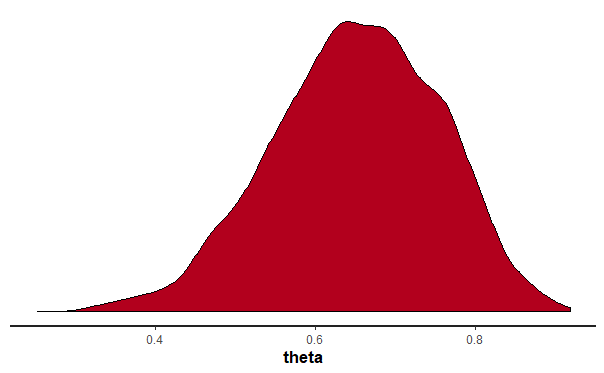

```r
stan_dens(fit_bin_unif)
```

Although it’s a little rough in shape due to the fact that the posterior is simulated, you can see that it’s close to the theoretically correct posterior shown in `Continuous_Bayes`. It will be easier to see if we put it on the same x-axis scale as it was there:

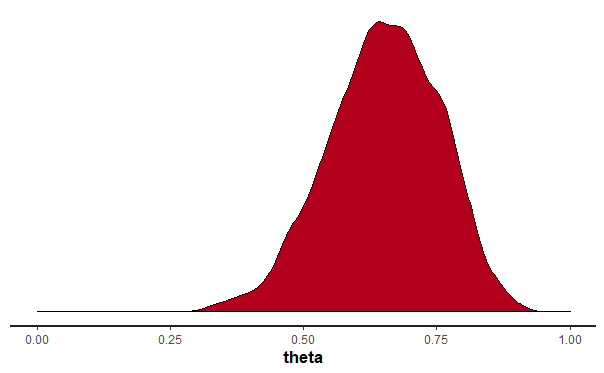

```r
stan_dens(fit_bin_unif) +
    xlim(0,1)
```

## Normal prior (far from data)

The next example in `Continuous_Bayes` is about selecting the normal prior

$$\theta \sim N(0.3, 0.1).$$

Here is the Stan code used to define this model. The only change is the line

```
theta ~ normal(0.3, 0.1);  // prior
```

in the `model` block.

Once again, we sample from the model using our data. We’ll also tell the code chunk to skip printing the output. (Well, it will hide the results in the HTML document. It doesn’t seem to hide the output in the R notebook for some reason.)

```r
fit_bin_norm1 <- sampling(bin_norm1,
                          data = stan_data)
```

```r
fit_bin_norm1
```

```
Inference for Stan model: stan-ca05b2e6de9.
4 chains, each with iter=2000; warmup=1000; thin=1;
post-warmup draws per chain=1000, total post-warmup draws=4000.

        mean se_mean   sd   2.5%    25%    50%    75%  97.5% n_eff Rhat
theta   0.46    0.00 0.07   0.32   0.41   0.46   0.51   0.61  1571    1
lp__  -16.22    0.02 0.74 -18.36 -16.39 -15.93 -15.74 -15.69  1539    1

Samples were drawn using NUTS(diag_e) at Wed Nov 14 16:23:45 2018.
For each parameter, n_eff is a crude measure of effective sample size,
and Rhat is the potential scale reduction factor on split chains (at
convergence, Rhat=1).
```

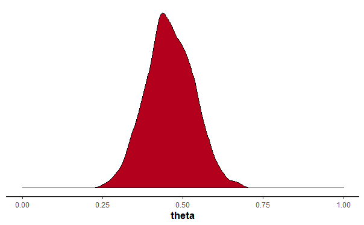

```r
stan_dens(fit_bin_norm1) +
    xlim(0,1)
```

Again, compare this to the theoretical posterior in the `Bayes.Rmd` notes: the mode is a little to the left of 0.5 and most of the distribution is concentrated between about 0.25 to 0.7 or so.

## Normal prior (close to data)

Suppose the prior is

$$\theta \sim N(0.7, 0.1).$$

```r
fit_bin_norm2 <- sampling(bin_norm2,
                          data = stan_data)
```

```r
fit_bin_norm2
```

```
Inference for Stan model: stan-ca01b0163d7.
4 chains, each with iter=2000; warmup=1000; thin=1;
post-warmup draws per chain=1000, total post-warmup draws=4000.

        mean se_mean   sd   2.5%    25%    50%    75%  97.5% n_eff Rhat
theta   0.68    0.00 0.07   0.53   0.63   0.68   0.73   0.82  1167    1
lp__  -13.55    0.02 0.79 -15.73 -13.72 -13.25 -13.06 -13.01  1147    1

Samples were drawn using NUTS(diag_e) at Wed Nov 14 16:25:07 2018.
For each parameter, n_eff is a crude measure of effective sample size,
and Rhat is the potential scale reduction factor on split chains (at
convergence, Rhat=1).
```

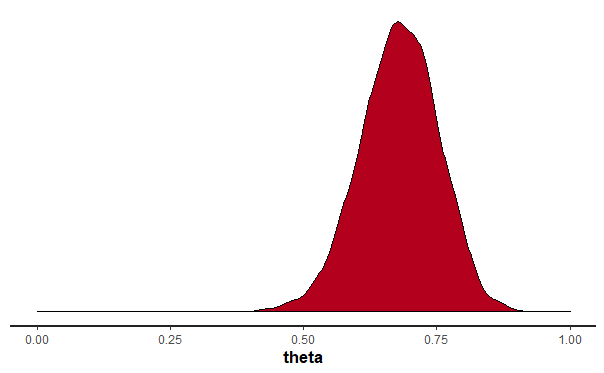

```r
stan_dens(fit_bin_norm2) +
    xlim(0,1)
```

## Triangular prior

Stan does not have a built-in expression for a triangular distribution, so we’ll leave that example out. (There is a hacky way to make it work, but it’s not really worth it. You don’t really want to use a triangular distribution for real-world problems anyway.)

## Change the data

The `Continuous_Bayes` file also shows the effect of the prior in situations of sparse data. What if we have only 2 successes in 3 trials?

```r
N <- 3  # Define the sample size
y <- c(1, 1, 0)  # 2 successes and 1 failure
stan_data_small <- list(N = N, y = y)
```

Let’s apply the three models already developed to this new data. Note that we do not need to run any more Stan code. This is just sampling from existing models using new data.

```r
fit_bin_unif_small <- sampling(bin_unif,
                               data = stan_data_small)
fit_bin_norm1_small <- sampling(bin_norm1,
                                data = stan_data_small)
fit_bin_norm2_small <- sampling(bin_norm2,
                                data = stan_data_small)
```

Summaries and plots:

```r
fit_bin_unif_small
```

```
Inference for Stan model: stan-ca029d86557.
4 chains, each with iter=2000; warmup=1000; thin=1;
post-warmup draws per chain=1000, total post-warmup draws=4000.

       mean se_mean   sd  2.5%   25%   50%   75% 97.5% n_eff Rhat
theta  0.60    0.01 0.20  0.19  0.45  0.62  0.76  0.94  1523    1
lp__  -3.94    0.02 0.77 -6.17 -4.14 -3.64 -3.43 -3.37  1601    1

Samples were drawn using NUTS(diag_e) at Wed Nov 14 16:25:14 2018.
For each parameter, n_eff is a crude measure of effective sample size,
and Rhat is the potential scale reduction factor on split chains (at
convergence, Rhat=1).
```

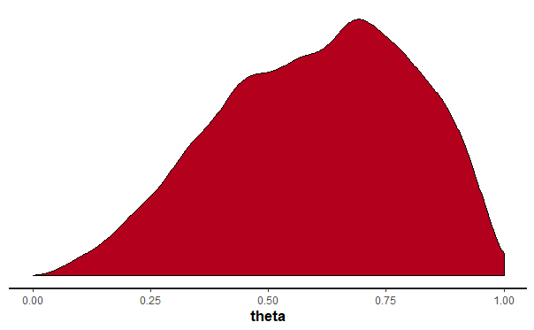

```r
stan_dens(fit_bin_unif_small) +
    xlim(0, 1)
```

```r
fit_bin_norm1_small
```

```
Inference for Stan model: stan-ca05b2e6de9.
4 chains, each with iter=2000; warmup=1000; thin=1;
post-warmup draws per chain=1000, total post-warmup draws=4000.

       mean se_mean   sd  2.5%   25%   50%   75% 97.5% n_eff Rhat
theta  0.35    0.00 0.09  0.17  0.29  0.35  0.41  0.53  1425    1
lp__  -4.67    0.02 0.79 -6.97 -4.82 -4.38 -4.19 -4.14  1271    1

Samples were drawn using NUTS(diag_e) at Wed Nov 14 16:25:19 2018.
For each parameter, n_eff is a crude measure of effective sample size,
and Rhat is the potential scale reduction factor on split chains (at
convergence, Rhat=1).
```

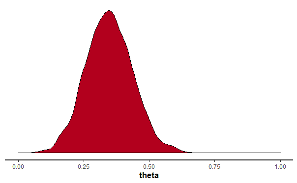

```r
stan_dens(fit_bin_norm1_small) +
    xlim(0, 1)
```

```r
fit_bin_norm2_small
```

```
Inference for Stan model: stan-ca01b0163d7.
4 chains, each with iter=2000; warmup=1000; thin=1;
post-warmup draws per chain=1000, total post-warmup draws=4000.

       mean se_mean   sd  2.5%   25%   50%   75% 97.5% n_eff Rhat
theta  0.69    0.00 0.09  0.52  0.63  0.69  0.76  0.87  1241 1.00
lp__  -4.02    0.03 0.81 -6.33 -4.18 -3.70 -3.51 -3.46   951 1.01

Samples were drawn using NUTS(diag_e) at Wed Nov 14 16:25:24 2018.
For each parameter, n_eff is a crude measure of effective sample size,
and Rhat is the potential scale reduction factor on split chains (at
convergence, Rhat=1).
```

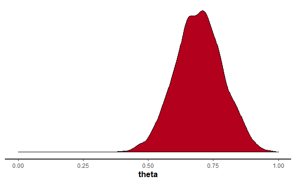

```r
stan_dens(fit_bin_norm2_small) +
    xlim(0, 1)
```

## ShinyStan

Shiny is a package that makes interactive web apps and dashboards for R. The Stan developers have created a beautiful dashboard that can be used to diagnose model fit and explore/visualize various properties of the posterior distribution.

In an R notebook, this won’t do anything. So go to the Console, and type the following:

```
launch_shinystan(fit_bin_norm1)
```

There is too much information there to talk about here, and much of it is highly technical. Nevertheless, you can click around and see what’s available. Also, in the “More” menu, there is a glossary that defines terms used throughout the dashboard.